# Score higher, longer, more python-y

```python
for c in df_merged.columns:
    if df_merged[str(c)].dtype == 'float64' or  df_merged[str(c)].dtype == 'int64':
        print(c, 'Max: {}, Min: {}'.format(df_merged[str(c)].max(), df_merged[str(c)].min()))
```

```
Participation_act Max: 1.0, Min: 0.08
English Max: 25.5, Min: 16.3
Math_act Max: 25.3, Min: 18.0
Reading Max: 26.0, Min: 18.1
Science Max: 24.9, Min: 2.3
Composite Max: 25.5, Min: 17.8
Participation_sat Max: 1.0, Min: 0.02
Evidence-Based Reading and Writing Max: 644, Min: 482
Math_sat Max: 651, Min: 52
Total Max: 1295, Min: 950
```

## Step 3: Visualize the data

```python
import matplotlib.pyplot as plt
```

```python
import seaborn as sns
```

```python
%config InlineBackend.figure_format = 'retina'
%matplotlib inline
```

##### 17. Plot the Math(s) distributions from both data sets.

```python
#So this returns a usable dataframe of only the numeric columns, which the question is not asking for
#I'm leaving it in here because it seems useful to me for later on
numcols = [col for col in df_merged.columns if df_merged[str(col)].dtype == 'float64' or df_merged[str(col)].dtype == 'int64']
df_merged[numcols].head()
```

|  | Participation_act | English | Math_act | Reading | Science | Composite | Participation_sat | Evidence-Based Reading and Writing | Math_sat | Total |
| --- | --- | --- | --- | --- | --- | --- | --- | --- | --- | --- |
| 0 | 1.00 | 18.9 | 18.4 | 19.7 | 19.4 | 19.2 | 0.05 | 593 | 572 | 1165 |
| 1 | 0.65 | 18.7 | 19.8 | 20.4 | 19.9 | 19.8 | 0.38 | 547 | 533 | 1080 |
| 2 | 0.62 | 18.6 | 19.8 | 20.1 | 19.8 | 19.7 | 0.30 | 563 | 553 | 1116 |
| 3 | 1.00 | 18.9 | 19.0 | 19.7 | 19.5 | 19.4 | 0.03 | 614 | 594 | 1208 |
| 4 | 0.31 | 22.5 | 22.7 | 23.1 | 22.2 | 22.8 | 0.53 | 531 | 524 | 1055 |

```python
math_scores = ['Math_act', 'Science', 'Math_sat']
verb_scores = ['English', 'Reading', 'Evidence-Based Reading and Writing']
```

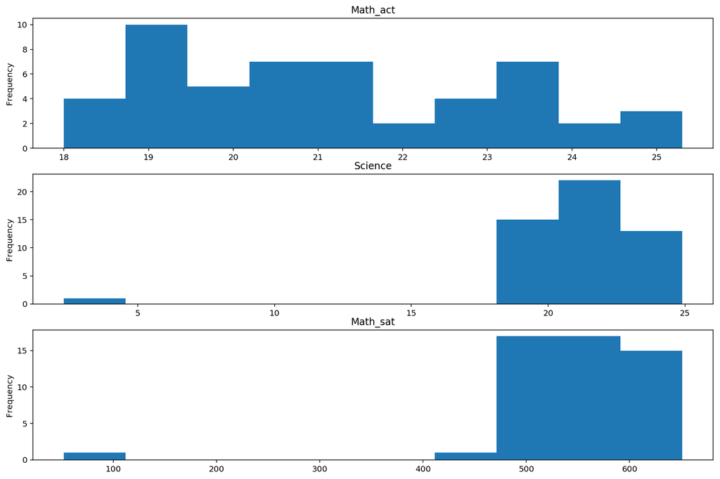

```python
fig, ax = plt.subplots(nrows=len(math_scores), figsize=(15,10))
for i in range(len(math_scores)):
    df_merged[math_scores].iloc[:,i].plot(ax=ax[i], kind = 'hist', title=math_scores[i])
```

##### 18. Plot the Verbal distributions from both data sets.

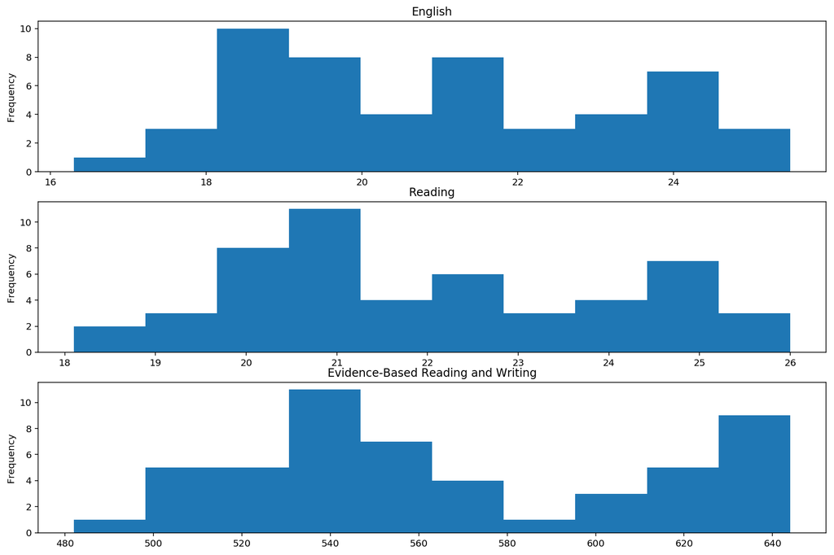

```python
fig, ax = plt.subplots(nrows=len(verb_scores), figsize=(15,10))
for i in range(len(verb_scores)):
    df_merged[verb_scores].iloc[:,i].plot(ax=ax[i], kind = 'hist', title=verb_scores[i])
```

##### 19. When we make assumptions about how data are distributed, what is the most common assumption?

Generall, that it is normal, or that it represents a single distribution

##### 20. Does this assumption hold true for any of our columns? Which?

```python
import scipy as sp
```

```python
for i in numcols:
    print(i, sp.stats.mstats.normaltest(df_merged[i]))
```

```
Participation_act NormaltestResult(statistic=72.50510406893649, pvalue=1.8018419611696658e-16)
English NormaltestResult(statistic=4.945616782086351, pvalue=0.08434764489205682)
Math_act NormaltestResult(statistic=6.547294554392776, pvalue=0.03786805958606832)
Reading NormaltestResult(statistic=6.248639549660324, pvalue=0.04396683079879635)
Science NormaltestResult(statistic=77.5558656361745, pvalue=1.441975088149312e-17)
Composite NormaltestResult(statistic=6.557389886662569, pvalue=0.03767739587231253)
Participation_sat NormaltestResult(statistic=24.84401282693096, pvalue=4.02894334576706e-06)
Evidence-Based Reading and Writing NormaltestResult(statistic=13.81815328788405, pvalue=0.0009986795076584)
Math_sat NormaltestResult(statistic=75.69485703674906, pvalue=3.656542623320732e-17)
Total NormaltestResult(statistic=9.607185954097002, pvalue=0.008200230814088539)
```

##### 21. Plot some scatterplots examining relationships between all variables.

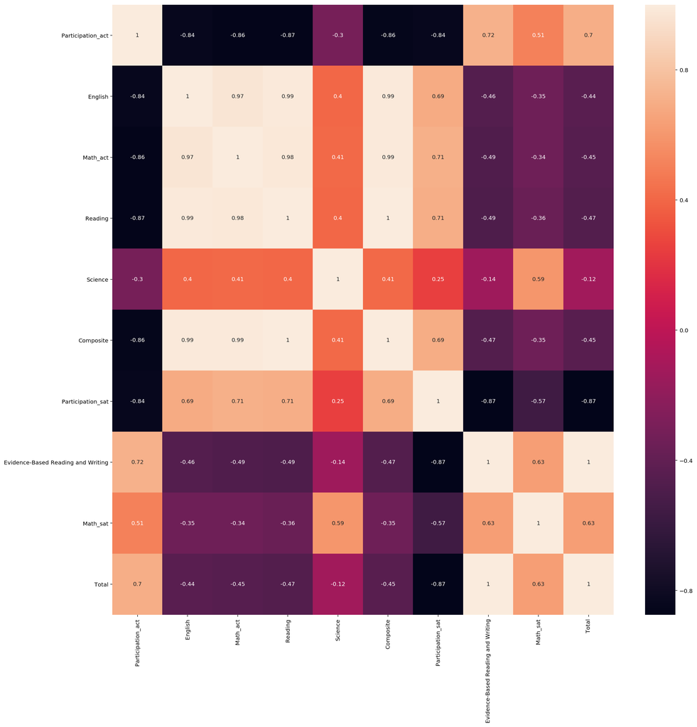

```python
plt.figure(figsize=(20,20))
sns.heatmap(df_merged[numcols].corr(), annot=True)
```

##### 22. Are there any interesting relationships to note?

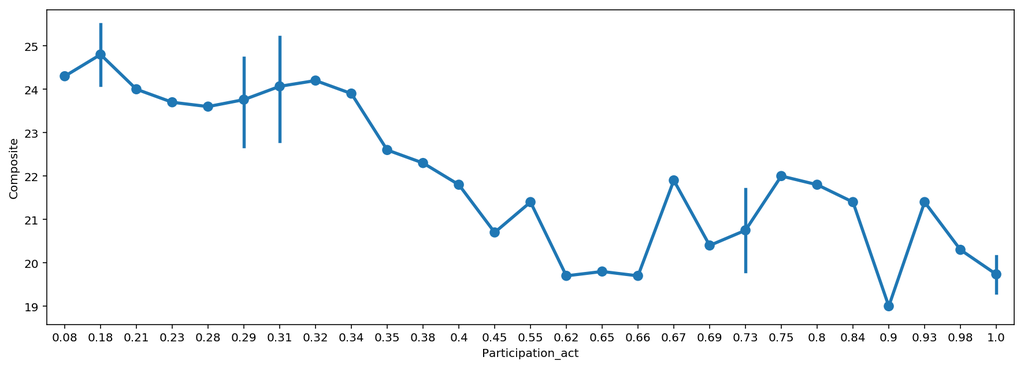

```python
plt.figure(figsize=(15,5))
sns.pointplot(x=df_merged['Participation_act'], y=df_merged['Composite'])
```

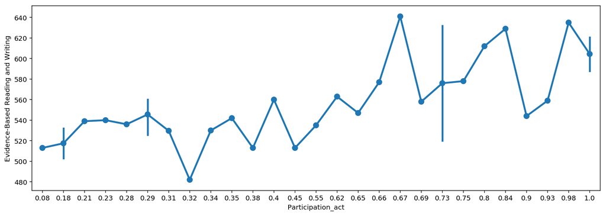

```python
plt.figure(figsize=(15,5))
sns.pointplot(x=df_merged['Participation_act'], y=df_merged['Evidence-Based Reading and Writing'])
```

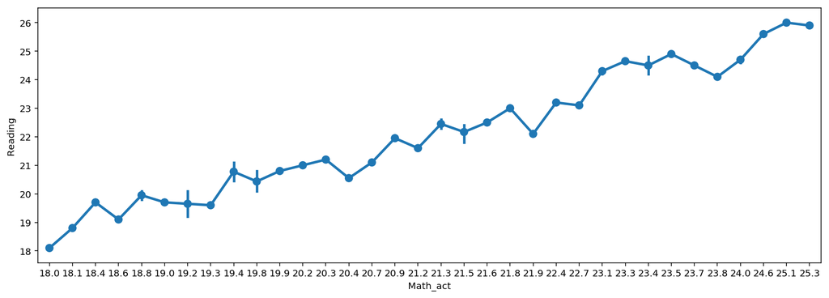

```python
plt.figure(figsize=(15,5))
sns.pointplot(x=df_merged['Math_act'], y=df_merged['Reading'])
```

##### 23. Create box plots for each variable.

```python
df_merged[numcols].columns
```

```
Index(['Participation_act', 'English', 'Math_act', 'Reading', 'Science',
       'Composite', 'Participation_sat', 'Evidence-Based Reading and Writing',
       'Math_sat', 'Total'],
      dtype='object')
```

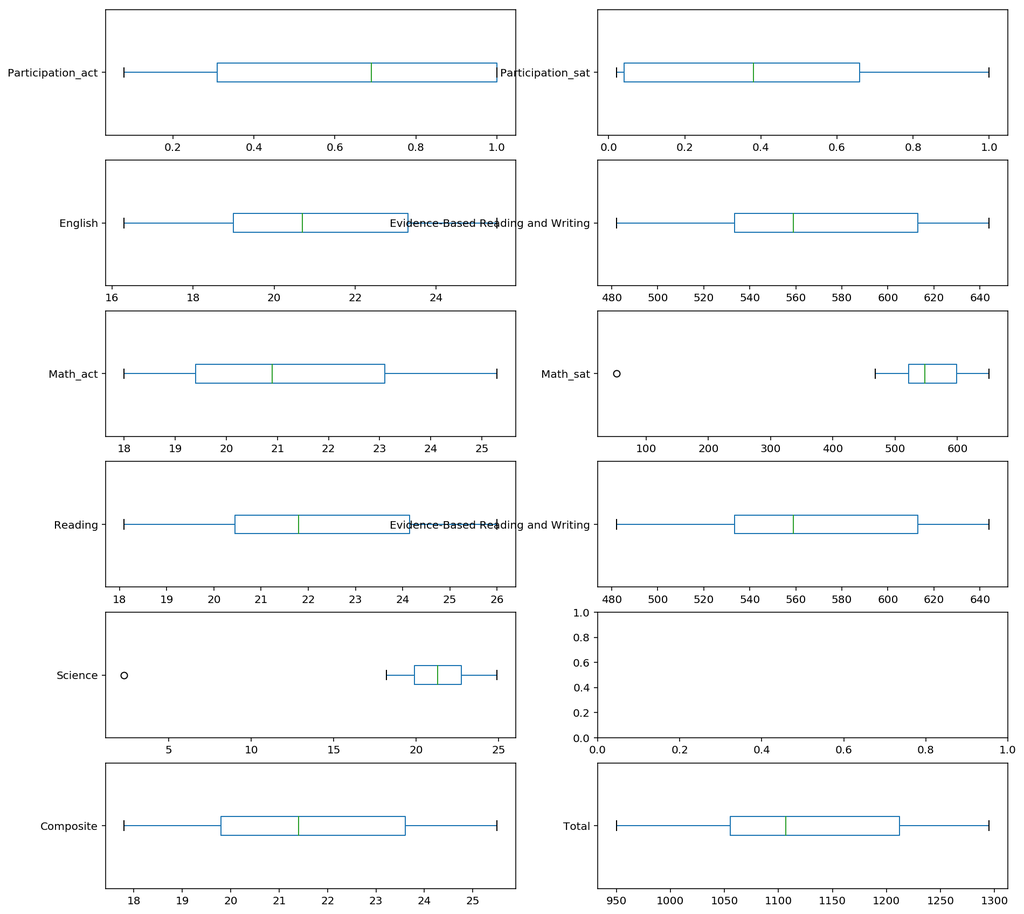

```python
fig, ax = plt.subplots(nrows=6, ncols=2, figsize=(15,15))
df_merged['Participation_act'].plot(kind='box', ax=ax[0,0], vert=False)
df_merged['English'].plot(kind='box', ax=ax[1,0], vert=False)
df_merged['Math_act'].plot(kind='box', ax=ax[2,0], vert=False)
df_merged['Reading'].plot(kind='box', ax=ax[3,0], vert=False)
df_merged['Science'].plot(kind='box', ax=ax[4,0], vert=False)
df_merged['Composite'].plot(kind='box', ax=ax[5,0], vert=False)

df_merged['Participation_sat'].plot(kind='box', ax=ax[0,1], vert=False)
df_merged['Evidence-Based Reading and Writing'].plot(kind='box', ax=ax[1,1], vert=False)
df_merged['Math_sat'].plot(kind='box', ax=ax[2,1], vert=False)
df_merged['Evidence-Based Reading and Writing'].plot(kind='box', ax=ax[3,1], vert=False)
df_merged['Total'].plot(kind='box', ax=ax[5,1], vert=False)
```

##### BONUS: Using Tableau, create a heat map for each variable using a map of the US.

## Step 4: Descriptive and Inferential Statistics

```python
import numpy as np
import scipy as sp
```

##### 24. Summarize each distribution. As data scientists, be sure to back up these summaries with statistics. (Hint: What are the three things we care about when describing distributions?)

```python
for c in numcols:
    print('{}:\n mean: {}\n median: {}\n C mode:{}\n'.format(
        c,
        round(df_merged[str(c)].mean(), 3),
        round(df_merged[str(c)].median(), 3),
        round(df_merged[str(c)].mode(), 3)
    ))
```

```
Participation_act:
 mean: 0.653
 median: 0.69
 C mode:0    1.0
dtype: float64

English:
 mean: 20.931
 median: 20.7
 C mode:0    19.0
1    19.5
2    21.2
dtype: float64

Math_act:
 mean: 21.182
 median: 20.9
 C mode:0    19.4
dtype: float64

Reading:
 mean: 22.014
 median: 21.8
 C mode:0    20.1
1    20.8
dtype: float64

Science:
 mean: 21.041
 median: 21.3
 C mode:0    20.5
1    20.6
2    20.9
3    22.0
dtype: float64

Composite:
 mean: 21.52
 median: 21.4
 C mode:0    19.8
```

[output cut: 19 more lines]

```
 median: 548.0
 C mode:0    524
1    541
2    551
3    553
4    604
dtype: int64

Total:
 mean: 1126.098
 median: 1107.0
 C mode:0    1005
1    1052
2    1116
dtype: int64
```

##### 25. Summarize each relationship. Be sure to back up these summaries with statistics.

```python
#Refer to correl matrix above
```

##### 26. Execute a hypothesis test comparing the SAT and ACT participation rates. Use $\alpha = 0.05$. Be sure to interpret your results.

### Hypothesis:

Participation rate in ACT is higher overall than SAT

1. Null: Participation Rates are the same
2. Alternative: Participation rates are different

```python
tstat, pval = sp.stats.ttest_ind(df_merged['Participation_act'], df_merged.Participation_sat)

print(round(tstat,2), round(pval, 4))
```

```
3.81 0.0002
```

pval < .001, so we can reject the null hypothesis that the average participation rate for the two tests is the same.

Below is a sample for what the two participation rate distributions would look like if they were normal.

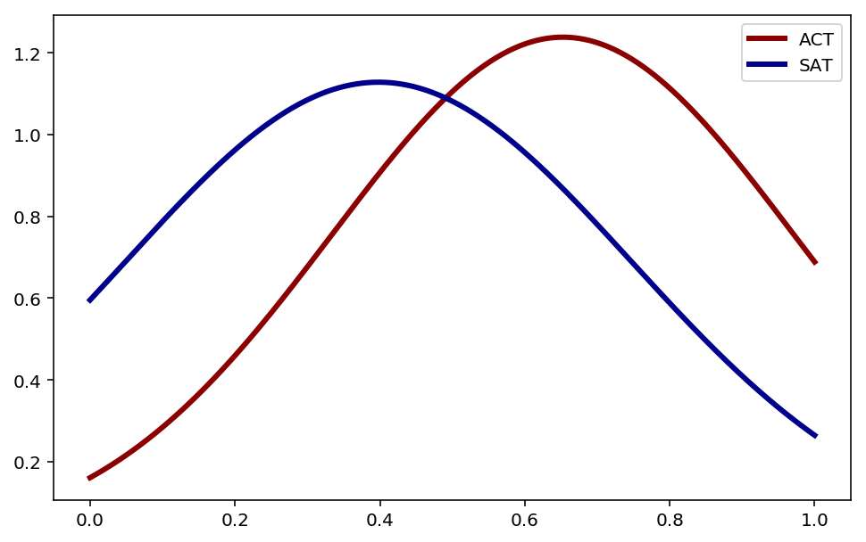

```python
xpoints = np.linspace(0, 1, 500)
ypoints = sp.stats.t.pdf(xpoints,
                      len(df_merged['Participation_act']) + len(df_merged.Participation_sat) - 2,
                      df_merged['Participation_act'].mean(), df_merged['Participation_act'].std())
ypoints2 = sp.stats.t.pdf(xpoints,
                      len(df_merged['Participation_act']) + len(df_merged.Participation_sat) - 2,
                      df_merged['Participation_sat'].mean(), df_merged['Participation_sat'].std())

# Initialize a `matplotlib` "figure."
fig, ax = plt.subplots(figsize=(8,5))

ax.plot(xpoints, ypoints, linewidth=3, color='darkred')
ax.plot(xpoints, ypoints2, linewidth=3, color='darkblue')
ax.legend(['ACT', 'SAT'])
```

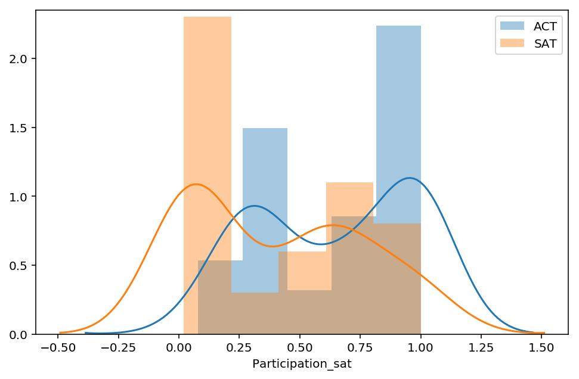

```python
xpoints = np.linspace(0, 1, 51)
ypoints = (df_merged.Participation_act)
ypoints2 = (df_merged.Participation_sat)

# Initialize a `matplotlib` "figure."
fig, ax = plt.subplots(figsize=(8,5))


sns.distplot(df_merged.Participation_act, bins=5)
sns.distplot(df_merged.Participation_sat, bins=5)
ax.legend(['ACT', 'SAT'])
```

##### 27. Generate and interpret 95% confidence intervals for SAT and ACT participation rates.

```python
print(sp.stats.norm.interval(0.95, df_merged['Participation_act'].mean(), df_merged['Participation_act'].std()))

print(sp.stats.norm.interval(0.95, df_merged['Participation_sat'].mean(), df_merged['Participation_sat'].std()))
```

```
(0.022600091768543606, 1.2824979474471425)
(-0.2933700717646155, 1.0894485031371646)
```

The interval results above assume a normal distribution, however the underlying values for this move outside the bounds. So, I will use the more literal method of counting up the 5th and 95th entries:

```python
#df.a.nlargest(3).iloc[-1]
act_95 = int(df_merged.Participation_act.count()*.95)
act_05 = int(df_merged.Participation_act.count()*.05)
sat_95 = int(df_merged.Participation_sat.count()*.95)
sat_05 = int(df_merged.Participation_sat.count()*.05)

print('ACT 95th:', df_merged.Participation_act.sort_values().iloc[act_95])
print('ACT 5th:', df_merged.Participation_act.sort_values().iloc[act_05])
print('SAT 95th:', df_merged.Participation_act.sort_values().iloc[sat_95])
print('SAT 5th:', df_merged.Participation_act.sort_values().iloc[sat_05])
```

```
ACT 95th: 1.0
ACT 5th: 0.18
SAT 95th: 1.0
SAT 5th: 0.18
```

##### 29. Is it appropriate to generate correlation between SAT and ACT math scores? Why?

Yes - both theoretically derive from the same underlying feature, i.e. math aptitude

##### 30. Suppose we only seek to understand the relationship between SAT and ACT data in 2017. Does it make sense to conduct statistical inference given the data we have? Why?

## Yes, sort of.

It depends on what relationship we're tracking. Any analysis should be limited to states with similar participation rates. There are many features of the data that would suggest high performing students branch out from whatever test is normal in their state to take the other, skewing the results for those states.

Similarly, it looks like for math, people tended to do better on one test or the other, so there may be some gaming going on here.

[output not shown]